# Stochastic Growth Exercises 4

Ferran Estrella Serra

2026-06-26

# Part 1: Hubbert Diffusion Process

## Exercise1 – BayesianInference of the Hubbert Diffusion Process: Complete Observation

Simulate a dataset of paths following a Hubbert diffusion process with the following parameters:

```r
true_eta   <- 0.01
true_alpha <- 0.85
true_sigma <- 0.06

t0 <- 1
tf <- 50
t_vec <- seq(t0, tf, length.out = 501)
n_time <- length(t_vec)

x0 <- 10

n_paths <- 50
```

```r
set.seed(123)
# Matrix to store simulated trajectories
sim_paths <- matrix(NA, nrow = n_time, ncol = n_paths)
sim_paths[1, ] <- x0

# Simulation loop using the exact Lognormal transition density
for (p in 1:n_paths) {
  for (i in 2:n_time) {
    s <- t_vec[i-1]
    t <- t_vec[i]
    dt <- t - s
    y_old <- log(sim_paths[i-1, p])

    # Lognormal mean parameter (mu) calculation
    mu <- y_old + 2*log(true_eta + true_alpha^s) - 2*log(true_eta + true_alpha^t) +
      (log(true_alpha) - 0.5 * true_sigma^2) * dt

    # Generate the next step
    sim_paths[i, p] <- exp(rnorm(1, mean = mu, sd = true_sigma * sqrt(dt))) #lognormal and normal distributions relation
  }
}

# Extract the mean curve across all simulated trajectories
mean_curve <- rowMeans(sim_paths)
```

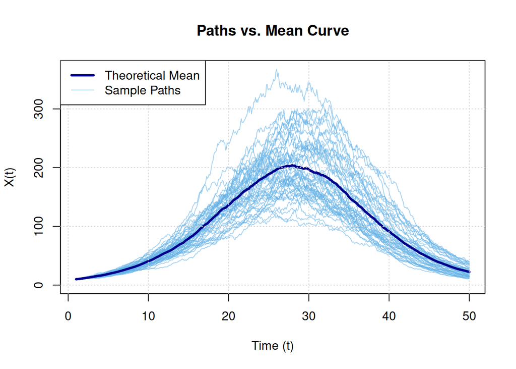

```r
plot(t_vec, mean_curve, type = 'l', col = 'darkblue', lwd = 3,
     ylim = c(0, max(sim_paths)), xlab = "Time (t)", ylab = "X(t)",
     main = "Paths vs. Mean Curve")
matlines(t_vec, sim_paths, type = 'l', lty = 1, col = rgb(0.4, 0.7, 0.9, 0.6))
lines(t_vec, mean_curve,
      col = "darkblue",
      lwd = 3)
grid()
legend("topleft", legend = c("Theoretical Mean", "Sample Paths"),
       col = c("darkblue", "lightblue"), lwd = c(3, 1))
```

1. Construct the likelihood function using the Gaussian transition density of the log-transformed process: Yt = log(Xt). Obtain the posterior distribution considering the likelihood function and the priors for the parameters.

```r
# Unnormalized Log-Posterior Target Function
log_posterior <- function(params, x_obs, t_vec) {
  # Map unconstrained real values back to positive parameter space (...)
  eta   <- exp(params[1])
  alpha <- exp(params[2])
  sigma <- exp(params[3])

  n <- length(x_obs)
  y <- log(x_obs) # log-transformation of the curve (nor params)

  # Log-priors: Gamma for eta/alpha, Half-Normal equivalent for sigma
  # Using weakly informative priors
  log_prior_eta   <- dgamma(eta, shape = 2, rate = 2, log = TRUE) # gamma (2,2)
  log_prior_alpha <- dgamma(alpha, shape = 2, rate = 2, log = TRUE) # gamma (2,2)
  log_prior_sigma <- dnorm(sigma, mean = 0, sd = 1, log = TRUE) # positive constraint already imposed

  # Log-Likelihood Evaluation: This is the construction of the likelihood function
  log_lik <- 0
  for (i in 2:n) {
    s <- t_vec[i-1]
    t <- t_vec[i]
    dt <- t - s

    mu_i <- y[i-1] + 2*log(eta + alpha^s) - 2*log(eta + alpha^t) +
      (log(alpha) - 0.5 * sigma^2) * dt

    log_lik <- log_lik - log(x_obs[i]) - 0.5*log(2*pi) - 0.5*log(sigma^2 * dt) -
      ((y[i] - mu_i)^2) / (2 * sigma^2 * dt) # expression (9) in slides, when iterated from 2 to n
  }

  # Jacobian adjustment for log-transforming parameters (!)
  jacobian_adjust <- params[1] + params[2] + params[3] # correction due to the transformation to positive parameter (pdf transformation theorem applied to the priors)

  return(log_lik + log_prior_eta + log_prior_alpha + log_prior_sigma + jacobian_adjust)
}
```

2. Implement an MCMC algorithm to estimate: (η,α,σ)

```r
set.seed(123)
# Metropolis-Hastings Sampler Function (Markov Chain Monte Carlo)
run_mcmc <- function(n_iter, initial_guess, x_obs, t_vec, prop_sd) {
  chain <- matrix(NA, nrow = n_iter, ncol = 3) # matrix of parameters at each iteration
  chain[1, ] <- log(initial_guess) # Work in log-space (...)

  accepted <- 0
  current_lp <- log_posterior(chain[1, ], x_obs, t_vec)

  for (iter in 2:n_iter) {
    # Propose new parameters using a Gaussian Random Walk
    proposal <- chain[iter-1, ] + rnorm(3, mean = 0, sd = prop_sd) # fixed st for the proposal step: prop_sd
    proposal_lp <- log_posterior(proposal, x_obs, t_vec)

    # Accept or Reject filter
    if (log(runif(1)) < (proposal_lp - current_lp)) { # expressions (3) and (4) from slides
      chain[iter, ] <- proposal
      current_lp <- proposal_lp
      accepted <- accepted + 1
    } else {
      chain[iter, ] <- chain[iter-1, ]
    }
  }

  cat("MCMC Acceptance Rate:", accepted / n_iter, "\n")
  return(exp(chain)) # Return parameters on original scale (...)
}
```

3. Compare posterior estimates with the true simulated values.

```r
set.seed(123)
mcmc_samples <- run_mcmc(
  n_iter = 20000,
  initial_guess = c(eta = 1.0, alpha = 1.0, sigma = 0.3),
  x_obs = mean_curve, # what we observe is the mean curve of all simulated curves
  t_vec = t_vec,
  prop_sd = 0.02
)
```

```
## MCMC Acceptance Rate: 0.05785
```

```r
# Burn-in phase exclusion (to ensure that only parameter samples from the convergence regime of the algorithm are considered. This excludes the initial iterations, during which the algorithm is still exploring the parameter space and has not yet reached its stationary distribution.)

burn_in <- 5000
final_chains <- mcmc_samples[(burn_in + 1):20000, ]
```

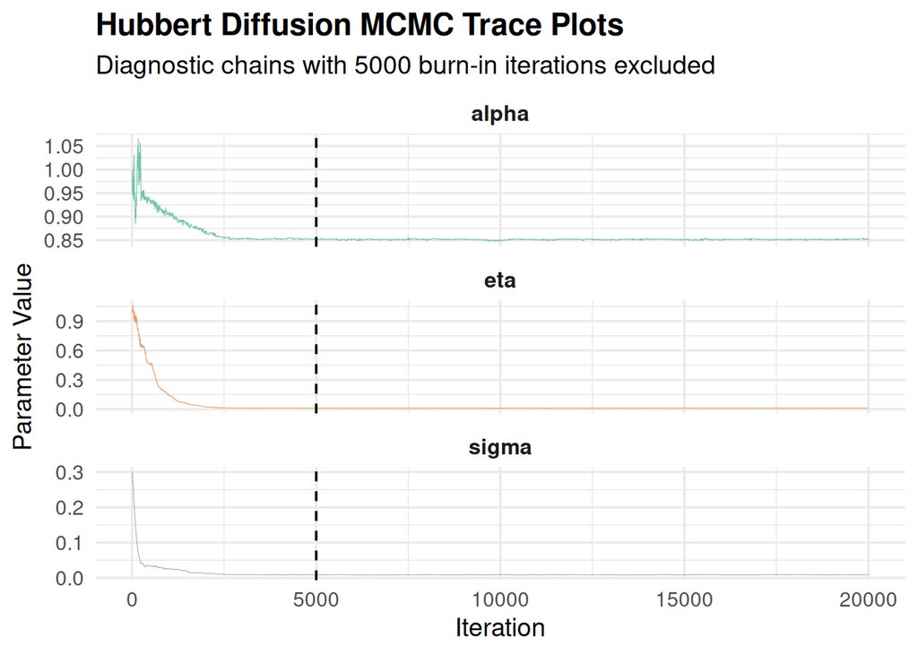

```r
library(ggplot2)
library(tidyr)


df_hubbert <- as.data.frame(mcmc_samples)
colnames(df_hubbert) <- c("eta", "alpha", "sigma")
df_hubbert$iteration <- 1:nrow(df_hubbert)
df_long_hubbert <- pivot_longer(
  df_hubbert,
  cols = c("eta", "alpha", "sigma"),
  names_to = "parameter",
  values_to = "value"
)

ggplot(df_long_hubbert, aes(x = iteration, y = value, color = parameter)) +
  geom_line(alpha = 0.6, size = 0.2) +
  geom_vline(xintercept = burn_in, linetype = "dashed", color = "black") + # Visual indicator of burn-in
  facet_wrap(~parameter, scales = "free_y", ncol = 1) +
  theme_minimal(base_size = 14) +
  labs(
    title = "Hubbert Diffusion MCMC Trace Plots",
    subtitle = paste("Diagnostic chains with", burn_in, "burn-in iterations excluded"),
    x = "Iteration",
    y = "Parameter Value"
  ) +
  theme(
    legend.position = "none",
    strip.text = element_text(face = "bold", size = 12),
    plot.title = element_text(face = "bold")
  ) +
  scale_color_brewer(palette = "Dark2")
```

```r
# Calculate Bayesian point estimates (Posterior Medians and 95% CI)
estimates <- apply(final_chains, 2, median)
lower_95  <- apply(final_chains, 2, quantile, probs = 0.025)
upper_95  <- apply(final_chains, 2, quantile, probs = 0.975)

names(estimates) <- c("eta", "alpha", "sigma")
names(lower_95)  <- c("eta", "alpha", "sigma")
names(upper_95)  <- c("eta", "alpha", "sigma")

cat("\n--- Parameter Estimation Results ---\n")
```

```
##
## --- Parameter Estimation Results ---
```

```r
cat("eta:\n")
```

```
## eta:
```

```r
cat("  True:", true_eta,
    " | Median:", round(estimates["eta"], 5),
    " | 95% CI: [", round(lower_95["eta"], 5), ",", round(upper_95["eta"], 5), "]\n")
```

```
##   True: 0.01  | Median: 0.01099  | 95% CI: [ 0.01003 , 0.01167 ]
```

```r
cat("alpha:\n")
```

```
## alpha:
```

```r
cat("  True:", true_alpha,
    " | Median:", round(estimates["alpha"], 5),
    " | 95% CI: [", round(lower_95["alpha"], 5), ",", round(upper_95["alpha"], 5), "]\n")
```

```
##   True: 0.85  | Median: 0.85137  | 95% CI: [ 0.84931 , 0.85309 ]
```

```r
cat("sigma:\n")
```

```
## sigma:
```

```r
cat("  True:", true_sigma,
    " | Median:", round(estimates["sigma"], 5),
    " | 95% CI: [", round(lower_95["sigma"], 5), ",", round(upper_95["sigma"], 5), "]\n")
```

```
##   True: 0.06  | Median: 0.00878  | 95% CI: [ 0.00822 , 0.00934 ]
```

4. Plot the simulated trajectories and the posterior mean trajectory using samples from the posterior distribution. Also plot the 95% credible interval.

```r
set.seed(123)
post <- final_chains
n_paths <- nrow(post)
n_time  <- length(t_vec)

sim_paths <- matrix(NA, nrow = n_time, ncol = n_paths)

sim_paths[1, ] <- x0

for (p in 1:n_paths) {
  eta   <- post[p, 1]
  alpha <- post[p, 2]
  sigma <- post[p, 3]

  for (i in 2:n_time) {
    s <- t_vec[i - 1]
    t <- t_vec[i]
    dt <- t - s

    y_old <- log(sim_paths[i - 1, p])

    mu <- y_old +
      2 * log(eta + alpha^s) -
      2 * log(eta + alpha^t) +
      (log(alpha) - 0.5 * sigma^2) * dt

    sim_paths[i, p] <- exp(rnorm(1, mean = mu, sd = sigma * sqrt(dt)))
  }
}

mean_curve <- rowMeans(sim_paths)
```

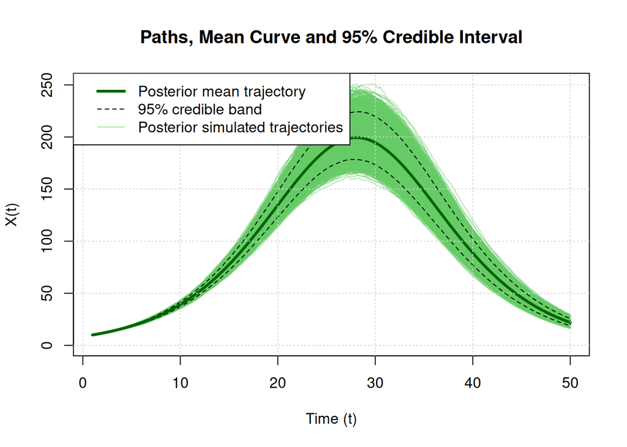

```r
# 95% credible interval
lower_95 <- apply(sim_paths, 1, quantile, probs = 0.025)
upper_95 <- apply(sim_paths, 1, quantile, probs = 0.975)

plot(t_vec, mean_curve, type = 'l', col = 'darkgreen', lwd = 3,
     ylim = c(0, max(sim_paths)),
     xlab = "Time (t)", ylab = "X(t)",
     main = "Paths, Mean Curve and 95% Credible Interval")

matlines(t_vec, sim_paths, type = "l", lty = 1,
         col = rgb(0.4, 0.8, 0.4, 0.5))

polygon(c(t_vec, rev(t_vec)),
        c(lower_95, rev(upper_95)),
        col = NA,
        border = "black",
        lty = 2)

lines(t_vec, mean_curve,
      col = "darkgreen",
      lwd = 3)

grid()

legend("topleft",
       legend = c("Posterior mean trajectory",
                  "95% credible band",
                  "Posterior simulated trajectories"),
       col = c("darkgreen", "black", "lightgreen"),
       lwd = c(3, 1, 1),
       lty = c(1, 2, 1),
       fill = c(NA, NA, NA),
       border = c(NA, NA, NA))
```

5. Discuss:
1. Is the posterior uncertainty small?

We observe that the simulated trajectories are dispersed and the credible band is wide. This indicates that the posterior uncertainty is large. In particular, there is significant variation in the peaks of the Hubbert curves. Note also that uncertainty increases as we approach the peak of the Hubbert curve, whereas it is lower away from the peak.

2. Which parameter is estimated with larger uncertainty?

σ is estimated with the lowest uncertainty, followed by η, while α has the highest uncertainty. This follows directly from the widths of the credible intervals. However, note that the estimate of σ is biased towards lower values; this behaviour is common in both Bayesian and non-Bayesian approaches.

3. Does increasing the number of trajectories improve estimation?

Increasing the number of simulated trajectories improves the Monte Carlo estimations of posterior predictive quantities, such as the mean trajectory and credible bands. However, it does not reduce the posterior uncertainty.

## Exercise 2– Bayesian Prediction of the Hubbert Peak From Truncated Data

Consider now a realistic situation where only the early growth phase of the process is observed. Using the same parameters as Exercise 1, generate trajectories only until t =22. The peak has not yet been observed.

```r
true_eta   <- 0.01
true_alpha <- 0.85
true_sigma <- 0.06

t0 <- 1
tf <- 22 # change
t_vec <- seq(t0, tf, length.out = 501)
n_time <- length(t_vec)

x0 <- 10

n_paths <- 50
```

```r
set.seed(123)
# Matrix to store simulated trajectories
sim_paths <- matrix(NA, nrow = n_time, ncol = n_paths)
sim_paths[1, ] <- x0

# Simulation loop using the exact Lognormal transition density
for (p in 1:n_paths) {
  for (i in 2:n_time) {
    s <- t_vec[i-1]
    t <- t_vec[i]
    dt <- t - s
    y_old <- log(sim_paths[i-1, p])

    # Lognormal mean parameter (mu) calculation
    mu <- y_old + 2*log(true_eta + true_alpha^s) - 2*log(true_eta + true_alpha^t) +
      (log(true_alpha) - 0.5 * true_sigma^2) * dt

    # Generate the next step
    sim_paths[i, p] <- exp(rnorm(1, mean = mu, sd = true_sigma * sqrt(dt))) #lognormal and normal distributions relation
  }
}

# Extract the mean curve across all simulated trajectories
mean_curve <- rowMeans(sim_paths)
```

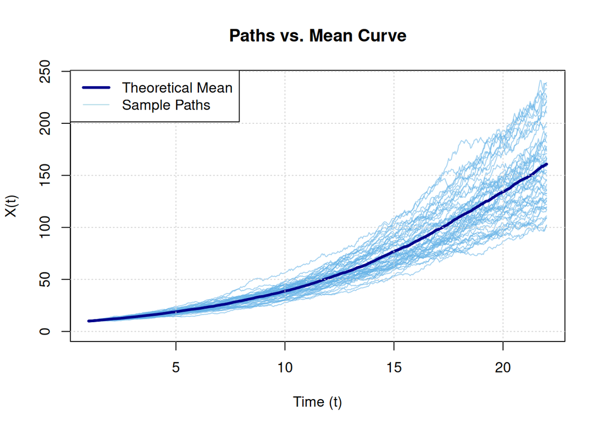

```r
plot(t_vec, mean_curve, type = 'l', col = 'darkblue', lwd = 3,
     ylim = c(0, max(sim_paths)), xlab = "Time (t)", ylab = "X(t)",
     main = "Paths vs. Mean Curve")
matlines(t_vec, sim_paths, type = 'l', lty = 1, col = rgb(0.4, 0.7, 0.9, 0.6))
lines(t_vec, mean_curve,
      col = "darkblue",
      lwd = 3)
grid()
legend("topleft", legend = c("Theoretical Mean", "Sample Paths"),
       col = c("darkblue", "lightblue"), lwd = c(3, 1))
```

1. Fit the Bayesian Hubbert model using only the truncated dataset.
2. Obtain posterior samples of: η,α,σ

```r
set.seed(123)
mcmc_samples <- run_mcmc(
  n_iter = 20000,
  initial_guess = c(eta = 1.0, alpha = 1.0, sigma = 0.3),
  x_obs = mean_curve, # what we observe is the mean curve of all simulated curves
  t_vec = t_vec,
  prop_sd = 0.02
)
```

```
## MCMC Acceptance Rate: 0.1571
```

```r
burn_in <- 5000
final_chains <- mcmc_samples[(burn_in + 1):20000, ]
```

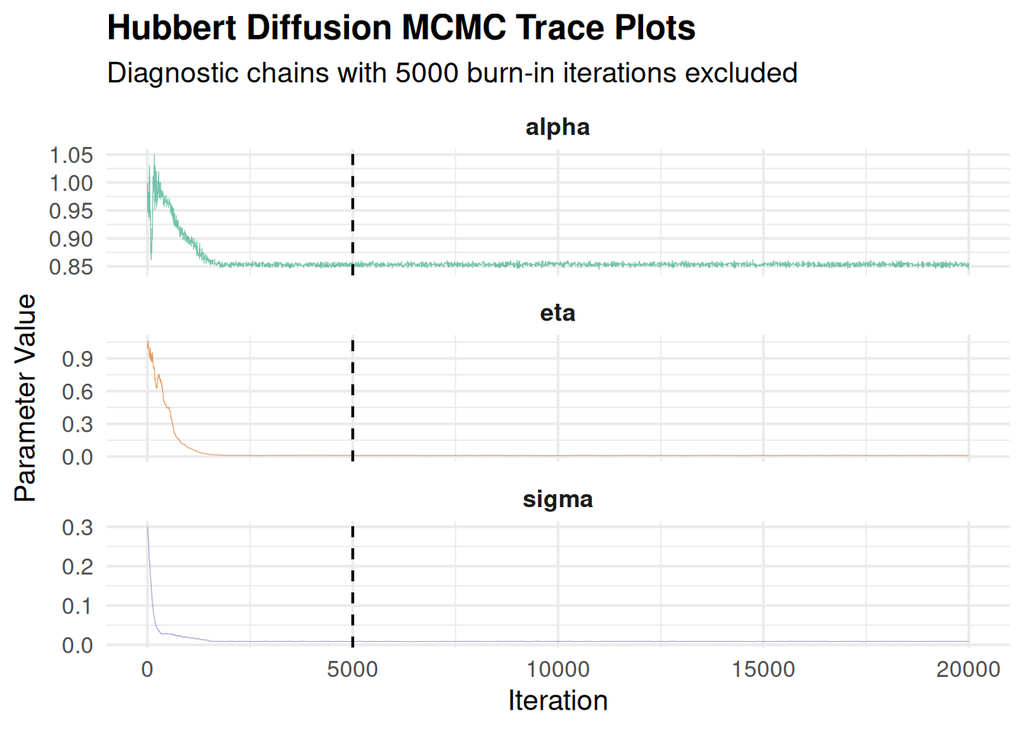

```r
library(ggplot2)
library(tidyr)


df_hubbert <- as.data.frame(mcmc_samples)
colnames(df_hubbert) <- c("eta", "alpha", "sigma")
df_hubbert$iteration <- 1:nrow(df_hubbert)
df_long_hubbert <- pivot_longer(
  df_hubbert,
  cols = c("eta", "alpha", "sigma"),
  names_to = "parameter",
  values_to = "value"
)

ggplot(df_long_hubbert, aes(x = iteration, y = value, color = parameter)) +
  geom_line(alpha = 0.6, size = 0.2) +
  geom_vline(xintercept = burn_in, linetype = "dashed", color = "black") + # Visual indicator of burn-in
  facet_wrap(~parameter, scales = "free_y", ncol = 1) +
  theme_minimal(base_size = 14) +
  labs(
    title = "Hubbert Diffusion MCMC Trace Plots",
    subtitle = paste("Diagnostic chains with", burn_in, "burn-in iterations excluded"),
    x = "Iteration",
    y = "Parameter Value"
  ) +
  theme(
    legend.position = "none",
    strip.text = element_text(face = "bold", size = 12),
    plot.title = element_text(face = "bold")
  ) +
  scale_color_brewer(palette = "Dark2")
```

```r
# Calculate Bayesian point estimates (Posterior Medians and 95% CI)
estimates <- apply(final_chains, 2, median)
lower_95  <- apply(final_chains, 2, quantile, probs = 0.025)
upper_95  <- apply(final_chains, 2, quantile, probs = 0.975)

names(estimates) <- c("eta", "alpha", "sigma")
names(lower_95)  <- c("eta", "alpha", "sigma")
names(upper_95)  <- c("eta", "alpha", "sigma")

cat("\n--- Parameter Estimation Results ---\n")
```

```
##
## --- Parameter Estimation Results ---
```

```r
cat("eta:\n")
```

```
## eta:
```

```r
cat("  True:", true_eta,
    " | Median:", round(estimates["eta"], 5),
    " | 95% CI: [", round(lower_95["eta"], 5), ",", round(upper_95["eta"], 5), "]\n")
```

```
##   True: 0.01  | Median: 0.0103  | 95% CI: [ 0.00908 , 0.01165 ]
```

```r
cat("alpha:\n")
```

```
## alpha:
```

```r
cat("  True:", true_alpha,
    " | Median:", round(estimates["alpha"], 5),
    " | 95% CI: [", round(lower_95["alpha"], 5), ",", round(upper_95["alpha"], 5), "]\n")
```

```
##   True: 0.85  | Median: 0.85352  | 95% CI: [ 0.84878 , 0.85803 ]
```

```r
cat("sigma:\n")
```

```
## sigma:
```

```r
cat("  True:", true_sigma,
    " | Median:", round(estimates["sigma"], 5),
    " | 95% CI: [", round(lower_95["sigma"], 5), ",", round(upper_95["sigma"], 5), "]\n")
```

```
##   True: 0.06  | Median: 0.00868  | 95% CI: [ 0.00811 , 0.00923 ]
```

3. Using posterior predictive simulation, forecast the process for 22 < t <50 (we forecast for the full time interval):

```r
set.seed(123)
# Now we sample trajectories for the full time-interval
tf <- 50
t_vec <- seq(t0, tf, length.out = 501)

post <- final_chains
n_paths <- nrow(post)
n_time  <- length(t_vec)

sim_paths <- matrix(NA, nrow = n_time, ncol = n_paths)

sim_paths[1, ] <- x0

for (p in 1:n_paths) {
  eta   <- post[p, 1]
  alpha <- post[p, 2]
  sigma <- post[p, 3]

  for (i in 2:n_time) {
    s <- t_vec[i - 1]
    t <- t_vec[i]
    dt <- t - s

    y_old <- log(sim_paths[i - 1, p])

    mu <- y_old +
      2 * log(eta + alpha^s) -
      2 * log(eta + alpha^t) +
      (log(alpha) - 0.5 * sigma^2) * dt

    sim_paths[i, p] <- exp(rnorm(1, mean = mu, sd = sigma * sqrt(dt)))
  }
}

mean_curve <- rowMeans(sim_paths)
```

Compute: posterior mean prediction, 2.5% percentile, 97.5% percentile:

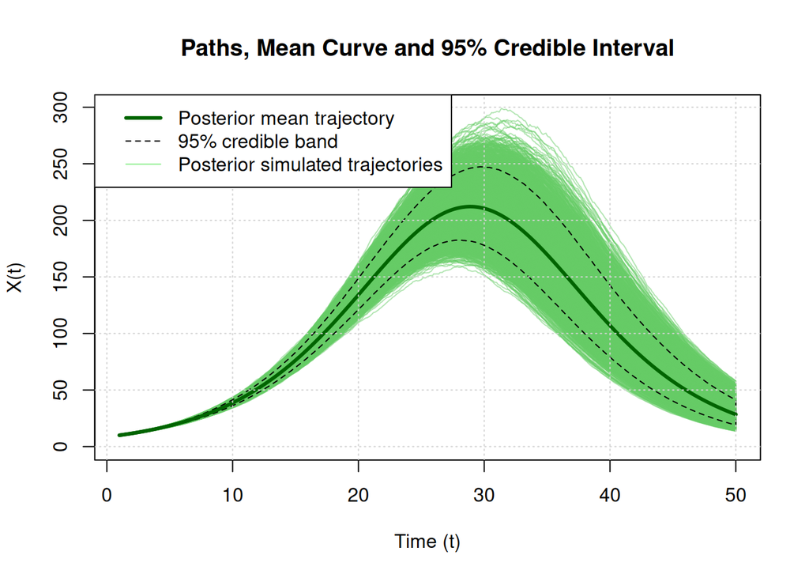

```r
# 95% credible interval
lower_95 <- apply(sim_paths, 1, quantile, probs = 0.025)
upper_95 <- apply(sim_paths, 1, quantile, probs = 0.975)

plot(t_vec, mean_curve, type = 'l', col = 'darkgreen', lwd = 3,
     ylim = c(0, max(sim_paths)),
     xlab = "Time (t)", ylab = "X(t)",
     main = "Paths, Mean Curve and 95% Credible Interval")

matlines(t_vec, sim_paths, type = "l", lty = 1,
         col = rgb(0.4, 0.8, 0.4, 0.5))

polygon(c(t_vec, rev(t_vec)),
        c(lower_95, rev(upper_95)),
        col = NA,
        border = "black",
        lty = 2)

lines(t_vec, mean_curve,
      col = "darkgreen",
      lwd = 3)

grid()

legend("topleft",
       legend = c("Posterior mean trajectory",
                  "95% credible band",
                  "Posterior simulated trajectories"),
       col = c("darkgreen", "black", "lightgreen"),
       lwd = c(3, 1, 1),
       lty = c(1, 2, 1),
       fill = c(NA, NA, NA),
       border = c(NA, NA, NA))
```

4. Estimate the distribution of the peak time. Define: Tpeak = argmax(X(t)). For each posterior trajectory compute Tpeak and plot the posterior distribution.

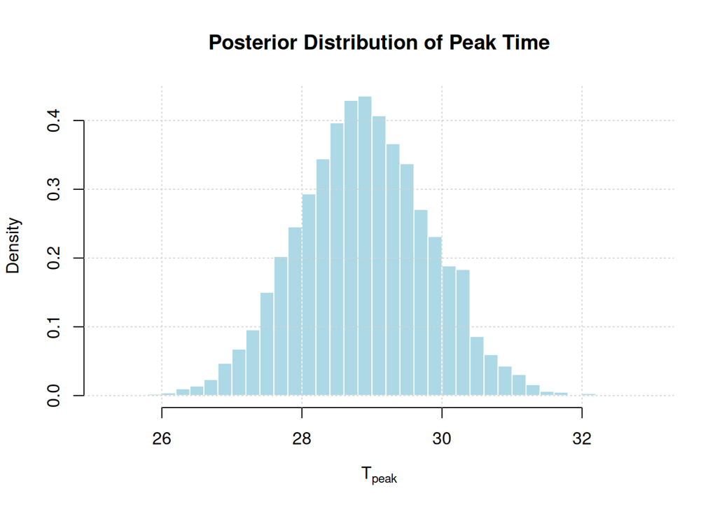

```r
t_peak_index <- apply(sim_paths, 2, which.max)
T_peak <- t_vec[t_peak_index]

hist(T_peak,
     breaks = 30,
     col = "lightblue",
     border = "white",
     main = "Posterior Distribution of Peak Time",
     xlab = expression(T[peak]),
     probability = TRUE)

grid()
```

5. Compare: predicted peak time, true peak time.

```r
(true_T_peak_ <- log(true_eta)/log(true_alpha))
```

```
## [1] 28.33621
```

```r
(estimated_T_peak <- mean(T_peak))
```

```
## [1] 28.88044
```

We obtain a Tpeak similar to that expected theoretically given the true parameter values.

6. Discuss the effect of missing the peak observation.

From the plot showing the simulated trajectories, the posterior mean trajectory, and the credible interval, we observe a narrow credible band over the observed interval and a much wider band around and beyond the peak. This is the expected behaviour, since the available data correspond only to the early growth phase, while the peak, which represents the most nonlinear part of the dynamics and is the most sensitive to noise, is not observed.

# Part 2: Pluri-Sigmoidal Diffusion Proces

## Exercise 3– Bayesian Inference for a Pluri-Sigmoidal Diffusion Process

Simulate a dataset of paths following a Pluri-Sigmoidal diffusion process with the following parameters:

```r
true_a0    <-  -4
true_a1    <- 0.675
true_a2    <- -0.045
true_a3    <- 0.001
true_sigma <-  0.06

t0 <- 1
tf <- 50
t_vec <- seq(t0, tf, length.out = 501)
n_time  <- length(t_vec)
n_paths <- 50
x0      <- 10
```

```r
set.seed(123)
# Helper function to evaluate the cubic polynomial Q(t)
eval_Q <- function(t, a) {
  return(a[1] + a[2]*t + a[3]*t^2 + a[4]*t^3)
}

# STOCHASTIC TRAJECTORY SIMULATION
sim_matrix <- matrix(NA, nrow = n_time, ncol = n_paths)
sim_matrix[1, ] <- x0

true_a_vec <- c(true_a0, true_a1, true_a2, true_a3)

for (p in 1:n_paths) {
  for (i in 2:n_time) {
    s <- t_vec[i-1]
    t <- t_vec[i]
    dt <- t - s
    y_old <- log(sim_matrix[i-1, p])

    # Lognormal parameter mapping from the slide specification
    mu <- y_old + log((1 + exp(-eval_Q(s, true_a_vec))) / (1 + exp(-eval_Q(t, true_a_vec)))) -
      0.5 * (true_sigma^2) * dt

    sim_matrix[i, p] <- exp(rnorm(1, mean = mu, sd = true_sigma * sqrt(dt)))
  }
}

# Extract the empirical mean curve across all generated realizations
mean_curve <- rowMeans(sim_matrix)
```

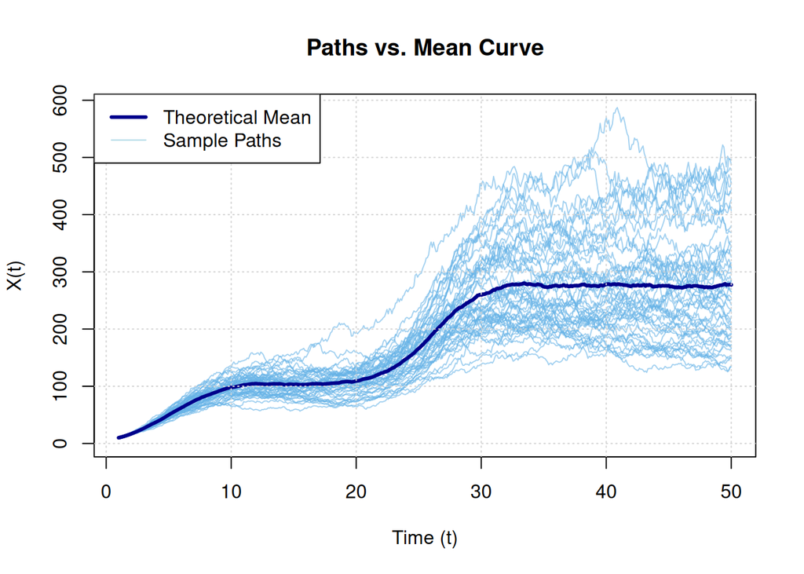

```r
plot(t_vec, mean_curve, type = 'l', col = 'darkblue', lwd = 3,
     ylim = c(0, max(sim_matrix)), xlab = "Time (t)", ylab = "X(t)",
     main = "Paths vs. Mean Curve")
matlines(t_vec, sim_matrix, type = 'l', lty = 1, col = rgb(0.4, 0.7, 0.9, 0.6))
lines(t_vec, mean_curve,
      col = "darkblue",
      lwd = 3)
grid()
legend("topleft", legend = c("Theoretical Mean", "Sample Paths"),
       col = c("darkblue", "lightblue"), lwd = c(3, 1))
```

1. Construct the likelihood function and obtain the posterior distribution considering the likelihood function and the priors for the parameters.

```r
set.seed(123)
log_posterior <- function(theta_unconstrained, x_obs, t_vec) {
  # Extract parameters (sigma is log-transformed to remain unconstrained)
  a_vec <- theta_unconstrained[1:4]
  sigma <- exp(theta_unconstrained[5])

  n <- length(x_obs)
  y <- log(x_obs)

  # Structural Priors
  log_prior_a     <- sum(dnorm(a_vec, mean = 0, sd = 10, log = TRUE))
  log_prior_sigma <- dnorm(sigma, mean = 0, sd = 1, log = TRUE) # Half-normal proxy

  # Evaluate Exact Markov Log-Likelihood
  log_lik <- 0
  for (i in 2:n) {
    s <- t_vec[i-1]
    t <- t_vec[i]
    dt <- t - s

    mu_i <- y[i-1] + log((1 + exp(-eval_Q(s, a_vec))) / (1 + exp(-eval_Q(t, a_vec)))) -
      0.5 * (sigma^2) * dt

    log_lik <- log_lik - log(x_obs[i]) - 0.5*log(2*pi) - 0.5*log(sigma^2 * dt) -
      ((y[i] - mu_i)^2) / (2 * sigma^2 * dt)
  }

  # Jacobian correction for the log transformation of sigma
  jacobian <- theta_unconstrained[5]

  return(log_lik + log_prior_a + log_prior_sigma + jacobian)
}
```

2. Implement an MCMC algorithm to estimate: (a0,a1,a2,a3,σ)

```r
set.seed(123)

# Random-Walk Metropolis-Hastings MCMC Engine

run_pluri_sigmoidal_mcmc <- function(n_iter, initial_guess, x_obs, t_vec, proposal_sd) {
  # 5 parâmetros: a0, a1, a2, a3, e log(sigma)
  chain <- matrix(NA, nrow = n_iter, ncol = 5)
  chain[1, ] <- c(initial_guess[1:4], log(initial_guess[5]))

  accepted <- 0
  current_lp <- log_posterior(chain[1, ], x_obs, t_vec)

  # Verificação de segurança para o chute inicial
  if (is.na(current_lp) || is.nan(current_lp) || is.infinite(current_lp)) {
    stop("O seu 'init_values' resultou em um log-posterior inválido (NA/NaN/Inf). Tente ajustar os valores iniciais.")
  }

  for (iter in 2:n_iter) {
    # Gerar proposta por caminhada aleatória gaussiana
    proposal <- chain[iter-1, ] + rnorm(5, mean = 0, sd = proposal_sd)
    proposal_lp <- log_posterior(proposal, x_obs, t_vec)

    # --- SALVAGUARDA NUMÉRICA CRÍTICA ---
    # Se a proposta cair em uma região instável, força o log-posterior a -Inf para rejeitá-la
    if (is.na(proposal_lp) || is.nan(proposal_lp)) {
      proposal_lp <- -Inf
    }

    # Critério de aceitação de Metropolis-Hastings
    if (log(runif(1)) < (proposal_lp - current_lp)) {
      chain[iter, ] <- proposal
      current_lp <- proposal_lp
      accepted <- accepted + 1
    } else {
      chain[iter, ] <- chain[iter-1, ]
    }
  }

  # Transforma o log(sigma) de volta para a escala original (positiva)
  chain[, 5] <- exp(chain[, 5])
  cat("MCMC Acceptance Optimization Rate:", round(accepted / n_iter, 4), "\n")
  return(chain)
}
```

3. Compare posterior estimates with the true simulated values.

```r
set.seed(123)
init_values <- c(
  a0 = -3.5,
  a1 = 0.6,
  a2 = -0.03,
  a3 = 0.001,
  sigma = 0.08
)

mcmc_output <- run_pluri_sigmoidal_mcmc(
  n_iter       = 30000,
  initial_guess = init_values,
  x_obs         = mean_curve,
  t_vec         = t_vec,
  proposal_sd   = 0.015
)
```

```
## MCMC Acceptance Optimization Rate: 0.0039
```

```r
# Burn-in truncation phase
burn_in <- 10000
post_burn_chain <- mcmc_output[(burn_in + 1):30000, ]
```

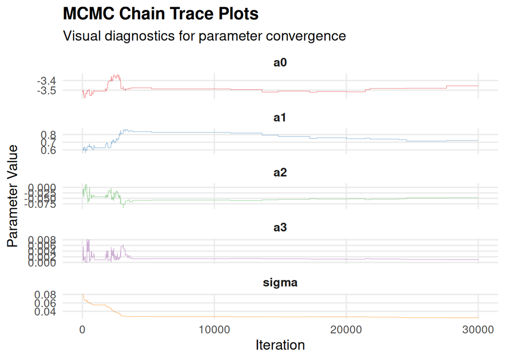

```r
library(ggplot2)
library(tidyr)
df_chain <- as.data.frame(mcmc_output)
colnames(df_chain) <- c("a0", "a1", "a2", "a3", "sigma")
df_chain$iteration <- 1:nrow(df_chain)
df_long <- pivot_longer(df_chain, cols = -iteration, names_to = "parameter", values_to = "value")
ggplot(df_long, aes(x = iteration, y = value, color = parameter)) +
  geom_line(alpha = 0.5, size = 0.25) +
  facet_wrap(~parameter, scales = "free_y", ncol = 1) +
  theme_minimal(base_size = 14) +
  labs(
    title = "MCMC Chain Trace Plots",
    subtitle = "Visual diagnostics for parameter convergence",
    x = "Iteration",
    y = "Parameter Value"
  ) +
  theme(
    legend.position = "none",
    strip.text = element_text(face = "bold", size = 12),
    panel.grid.minor = element_blank(),
    plot.title = element_text(face = "bold")
  ) +
  scale_color_brewer(palette = "Set1")
```

```r
# Calculate Bayesian point estimates (Posterior Medians and 95% CI)
estimates <- apply(post_burn_chain, 2, median)
lower_95  <- apply(post_burn_chain, 2, quantile, probs = 0.025)
upper_95  <- apply(post_burn_chain, 2, quantile, probs = 0.975)

param_names <- c("a0", "a1", "a2", "a3", "sigma")
true_values <- c(
  a0    = true_a0,
  a1    = true_a1,
  a2    = true_a2,
  a3    = true_a3,
  sigma = true_sigma
)

names(estimates) <- param_names
names(lower_95)  <- param_names
names(upper_95)  <- param_names

cat("\n--- Parameter Estimation Results ---\n\n")
```

```
##
## --- Parameter Estimation Results ---
```

```r
for (param in param_names) {
  cat(param, ":\n", sep = "")
  cat("  True:", true_values[param],
      " | Median:", round(estimates[param], 5),
      " | 95% CI: [", round(lower_95[param], 5), ",",
      round(upper_95[param], 5), "]\n")
}
```

```
## a0:
##   True: -4  | Median: -3.49338  | 95% CI: [ -3.52218 , -3.45477 ]
## a1:
##   True: 0.675  | Median: 0.7487  | 95% CI: [ 0.71519 , 0.82821 ]
## a2:
##   True: -0.045  | Median: -0.05338  | 95% CI: [ -0.06043 , -0.04776 ]
## a3:
##   True: 0.001  | Median: 0.00117  | 95% CI: [ 0.00103 , 0.00139 ]
## sigma:
##   True: 0.06  | Median: 0.02673  | 95% CI: [ 0.02475 , 0.02745 ]
```

4. Plot the simulated trajectories and the posterior mean trajectory using samples from the posterior distribution. Also plot the 95% credible interval.

```r
set.seed(123)

post <- post_burn_chain
n_paths <- nrow(post)
n_time <- length(t_vec)

# Helper function to evaluate the cubic polynomial Q(t)
eval_Q <- function(t, a) {
  a[1] + a[2] * t + a[3] * t^2 + a[4] * t^3
}

# Matrix to store posterior predictive trajectories
sim_matrix <- matrix(NA, nrow = n_time, ncol = n_paths)
sim_matrix[1, ] <- x0

for (p in 1:n_paths) {

  # Extract posterior sample
  a_vec  <- post[p, 1:4]
  sigma  <- post[p, 5]

  for (i in 2:n_time) {
    s  <- t_vec[i - 1]
    t  <- t_vec[i]
    dt <- t - s

    y_old <- log(sim_matrix[i - 1, p])

    # Conditional mean of the lognormal transition
    mu <- y_old +
      log((1 + exp(-eval_Q(s, a_vec))) /
            (1 + exp(-eval_Q(t, a_vec)))) -
      0.5 * sigma^2 * dt

    # Simulate next state
    sim_matrix[i, p] <- exp(
      rnorm(1, mean = mu, sd = sigma * sqrt(dt))
    )
  }
}

# Posterior mean trajectory
mean_curve <- rowMeans(sim_matrix)
```

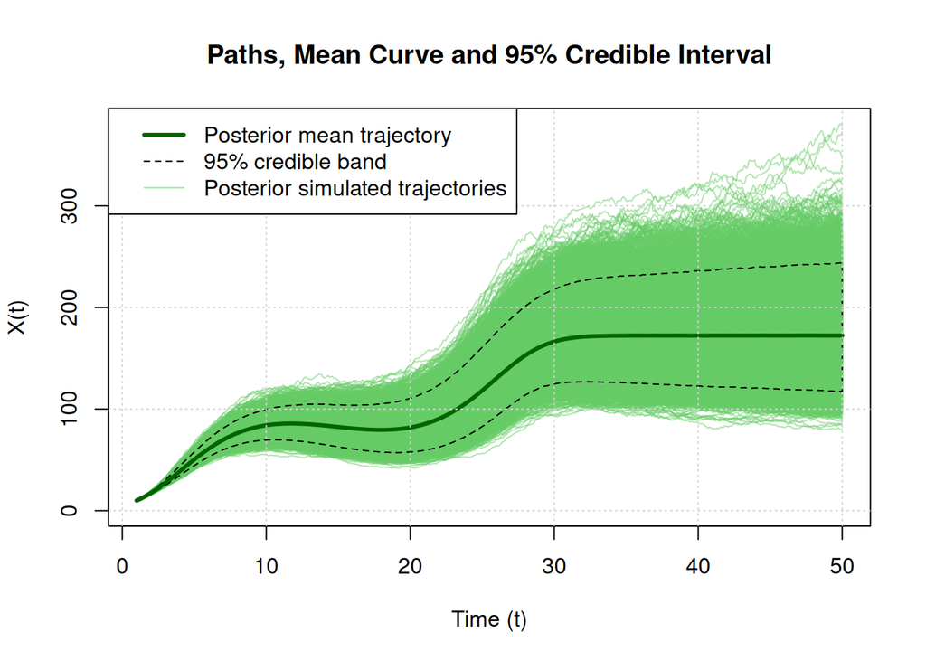

```r
# 95% credible interval
lower_95 <- apply(sim_matrix, 1, quantile, probs = 0.025)
upper_95 <- apply(sim_matrix, 1, quantile, probs = 0.975)

plot(t_vec, mean_curve, type = 'l', col = 'darkgreen', lwd = 3,
     ylim = c(0, max(sim_matrix)),
     xlab = "Time (t)", ylab = "X(t)",
     main = "Paths, Mean Curve and 95% Credible Interval")

matlines(t_vec, sim_matrix, type = "l", lty = 1,
         col = rgb(0.4, 0.8, 0.4, 0.5))

polygon(c(t_vec, rev(t_vec)),
        c(lower_95, rev(upper_95)),
        col = NA,
        border = "black",
        lty = 2)

lines(t_vec, mean_curve,
      col = "darkgreen",
      lwd = 3)

grid()

legend("topleft",
       legend = c("Posterior mean trajectory",
                  "95% credible band",
                  "Posterior simulated trajectories"),
       col = c("darkgreen", "black", "lightgreen"),
       lwd = c(3, 1, 1),
       lty = c(1, 2, 1),
       fill = c(NA, NA, NA),
       border = c(NA, NA, NA))
```

5. Evaluate whether the posterior model recovers the multiple growth cycles.

As observed in the previous plot, the posterior model recovers the two distinct growth cycles of the simulated dataset.

6. Discuss parameter identifiability. Which coefficients show the largest posterior variance?

Parameter identifiability can be observed from the widths of the posterior credible intervals. Among the estimated parameters, a1 exhibits the largest posterior uncertainty, which indicates that it is the least identifiable coefficient. This is followed by a0, whose posterior distribution is also relatively dispersed. In contrast, a3 and σ have the narrowest credible intervals, indicating that they are the best identified parameters.

## Exercise 4– Bayesian Forecasting of the Pluri-Sigmoidal Process Under Truncation

Repeat Exercise 3 but assume that observations are available only until t =22. This means that the second cycle has been partially observed, but later dynamics remain unknown.

```r
true_a0    <-  -4
true_a1    <- 0.675
true_a2    <- -0.045
true_a3    <- 0.001
true_sigma <-  0.06

t0 <- 1
tf <- 22 #change
t_vec <- seq(t0, tf, length.out = 501)
n_time  <- length(t_vec)
n_paths <- 50
x0      <- 10
```

```r
set.seed(123)
# Helper function to evaluate the cubic polynomial Q(t)
eval_Q <- function(t, a) {
  return(a[1] + a[2]*t + a[3]*t^2 + a[4]*t^3)
}

# STOCHASTIC TRAJECTORY SIMULATION
sim_matrix <- matrix(NA, nrow = n_time, ncol = n_paths)
sim_matrix[1, ] <- x0

true_a_vec <- c(true_a0, true_a1, true_a2, true_a3)

for (p in 1:n_paths) {
  for (i in 2:n_time) {
    s <- t_vec[i-1]
    t <- t_vec[i]
    dt <- t - s
    y_old <- log(sim_matrix[i-1, p])

    # Lognormal parameter mapping from the slide specification
    mu <- y_old + log((1 + exp(-eval_Q(s, true_a_vec))) / (1 + exp(-eval_Q(t, true_a_vec)))) -
      0.5 * (true_sigma^2) * dt

    sim_matrix[i, p] <- exp(rnorm(1, mean = mu, sd = true_sigma * sqrt(dt)))
  }
}

# Extract the empirical mean curve across all generated realizations
mean_curve <- rowMeans(sim_matrix)
```

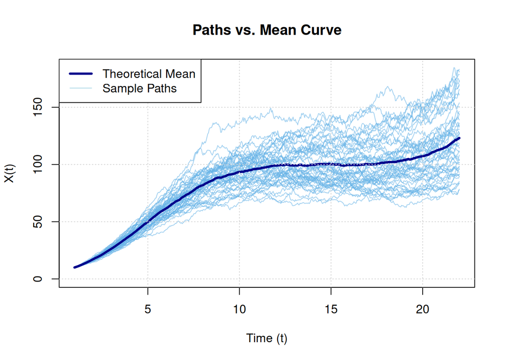

```r
plot(t_vec, mean_curve, type = 'l', col = 'darkblue', lwd = 3,
     ylim = c(0, max(sim_matrix)), xlab = "Time (t)", ylab = "X(t)",
     main = "Paths vs. Mean Curve")
matlines(t_vec, sim_matrix, type = 'l', lty = 1, col = rgb(0.4, 0.7, 0.9, 0.6))
lines(t_vec, mean_curve,
      col = "darkblue",
      lwd = 3)
grid()
legend("topleft", legend = c("Theoretical Mean", "Sample Paths"),
       col = c("darkblue", "lightblue"), lwd = c(3, 1))
```

1. Fit the Bayesian model using truncated observations.

```r
set.seed(123)
init_values <- c(
  a0 = -3.5,
  a1 = 0.6,
  a2 = -0.03,
  a3 = 0.001,
  sigma = 0.08
)

mcmc_output <- run_pluri_sigmoidal_mcmc(
  n_iter       = 30000,
  initial_guess = init_values,
  x_obs         = mean_curve,
  t_vec         = t_vec,
  proposal_sd   = 0.015
)
```

```
## MCMC Acceptance Optimization Rate: 0.0042
```

```r
# Burn-in truncation phase
burn_in <- 10000
post_burn_chain <- mcmc_output[(burn_in + 1):30000, ]
```

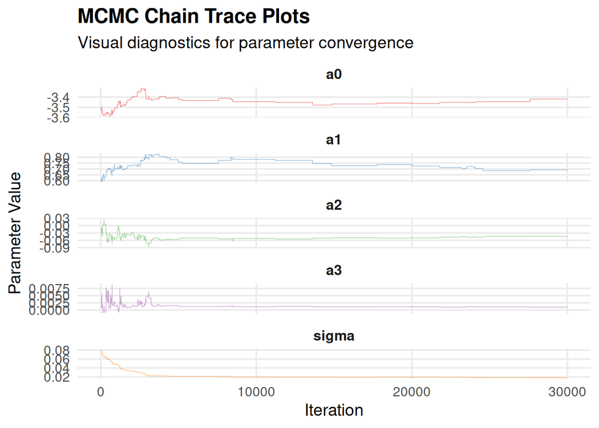

```r
library(ggplot2)
library(tidyr)
df_chain <- as.data.frame(mcmc_output)
colnames(df_chain) <- c("a0", "a1", "a2", "a3", "sigma")
df_chain$iteration <- 1:nrow(df_chain)
df_long <- pivot_longer(df_chain, cols = -iteration, names_to = "parameter", values_to = "value")
ggplot(df_long, aes(x = iteration, y = value, color = parameter)) +
  geom_line(alpha = 0.5, size = 0.25) +
  facet_wrap(~parameter, scales = "free_y", ncol = 1) +
  theme_minimal(base_size = 14) +
  labs(
    title = "MCMC Chain Trace Plots",
    subtitle = "Visual diagnostics for parameter convergence",
    x = "Iteration",
    y = "Parameter Value"
  ) +
  theme(
    legend.position = "none",
    strip.text = element_text(face = "bold", size = 12),
    panel.grid.minor = element_blank(),
    plot.title = element_text(face = "bold")
  ) +
  scale_color_brewer(palette = "Set1")
```

```r
# Calculate Bayesian point estimates (Posterior Medians and 95% CI)
estimates <- apply(post_burn_chain, 2, median)
lower_95  <- apply(post_burn_chain, 2, quantile, probs = 0.025)
upper_95  <- apply(post_burn_chain, 2, quantile, probs = 0.975)

param_names <- c("a0", "a1", "a2", "a3", "sigma")
true_values <- c(
  a0    = true_a0,
  a1    = true_a1,
  a2    = true_a2,
  a3    = true_a3,
  sigma = true_sigma
)

names(estimates) <- param_names
names(lower_95)  <- param_names
names(upper_95)  <- param_names

cat("\n--- Parameter Estimation Results ---\n\n")
```

```
##
## --- Parameter Estimation Results ---
```

```r
for (param in param_names) {
  cat(param, ":\n", sep = "")
  cat("  True:", true_values[param],
      " | Median:", round(estimates[param], 5),
      " | 95% CI: [", round(lower_95[param], 5), ",",
      round(upper_95[param], 5), "]\n")
}
```

```
## a0:
##   True: -4  | Median: -3.45114  | 95% CI: [ -3.47737 , -3.41876 ]
## a1:
##   True: 0.675  | Median: 0.72792  | 95% CI: [ 0.68561 , 0.7817 ]
## a2:
##   True: -0.045  | Median: -0.04936  | 95% CI: [ -0.05448 , -0.04365 ]
## a3:
##   True: 0.001  | Median: 0.00115  | 95% CI: [ 0.001 , 0.00125 ]
## sigma:
##   True: 0.06  | Median: 0.01924  | 95% CI: [ 0.01807 , 0.01978 ]
```

2. Using posterior predictive simulation, forecast the process for 22 < t <50 (we forecast for the full time interval):

```r
set.seed(123)
# Now we sample trajectories for the full time-interval
tf <- 50
t_vec <- seq(t0, tf, length.out = 501)

post <- post_burn_chain
n_paths <- nrow(post)
n_time <- length(t_vec)

# Helper function to evaluate the cubic polynomial Q(t)
eval_Q <- function(t, a) {
  a[1] + a[2] * t + a[3] * t^2 + a[4] * t^3
}

# Matrix to store posterior predictive trajectories
sim_matrix <- matrix(NA, nrow = n_time, ncol = n_paths)
sim_matrix[1, ] <- x0

for (p in 1:n_paths) {

  # Extract posterior sample
  a_vec  <- post[p, 1:4]
  sigma  <- post[p, 5]

  for (i in 2:n_time) {
    s  <- t_vec[i - 1]
    t  <- t_vec[i]
    dt <- t - s

    y_old <- log(sim_matrix[i - 1, p])

    # Conditional mean of the lognormal transition
    mu <- y_old +
      log((1 + exp(-eval_Q(s, a_vec))) /
            (1 + exp(-eval_Q(t, a_vec)))) -
      0.5 * sigma^2 * dt

    # Simulate next state
    sim_matrix[i, p] <- exp(
      rnorm(1, mean = mu, sd = sigma * sqrt(dt))
    )
  }
}

# Posterior mean trajectory
mean_curve <- rowMeans(sim_matrix)
```

3. Plot the simulated trajectories and the posterior mean trajectory using samples from the posterior distribution. Also plot the 95% credible interval.

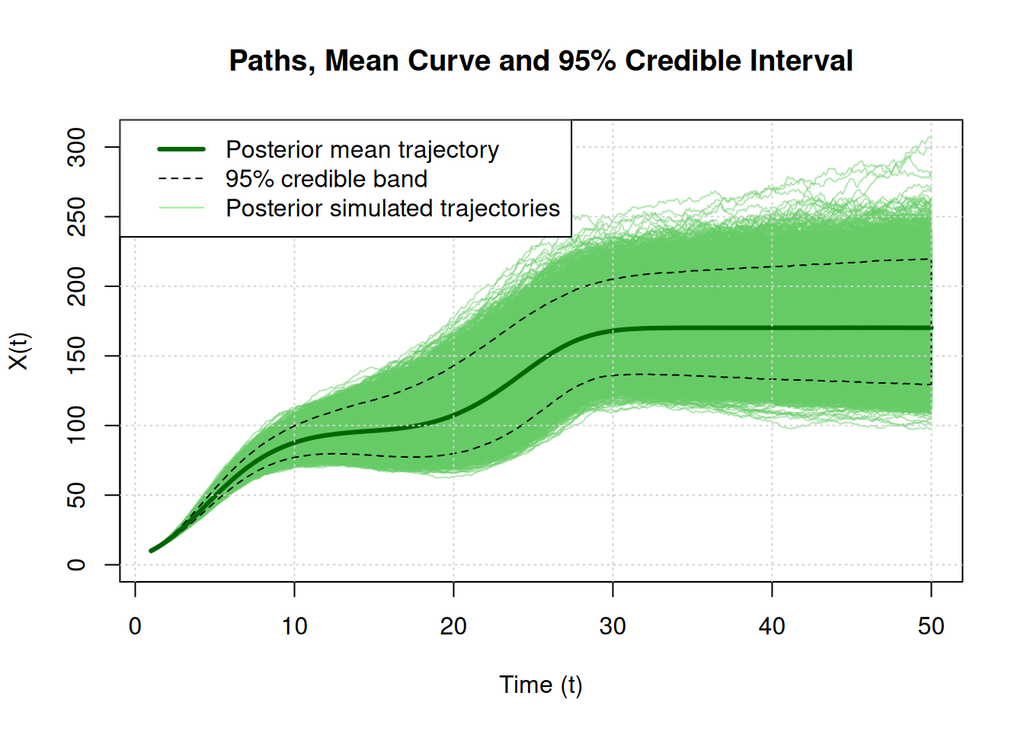

```r
# 95% credible interval
lower_95 <- apply(sim_matrix, 1, quantile, probs = 0.025)
upper_95 <- apply(sim_matrix, 1, quantile, probs = 0.975)

plot(t_vec, mean_curve, type = 'l', col = 'darkgreen', lwd = 3,
     ylim = c(0, max(sim_matrix)),
     xlab = "Time (t)", ylab = "X(t)",
     main = "Paths, Mean Curve and 95% Credible Interval")

matlines(t_vec, sim_matrix, type = "l", lty = 1,
         col = rgb(0.4, 0.8, 0.4, 0.5))

polygon(c(t_vec, rev(t_vec)),
        c(lower_95, rev(upper_95)),
        col = NA,
        border = "black",
        lty = 2)

lines(t_vec, mean_curve,
      col = "darkgreen",
      lwd = 3)

grid()

legend("topleft",
       legend = c("Posterior mean trajectory",
                  "95% credible band",
                  "Posterior simulated trajectories"),
       col = c("darkgreen", "black", "lightgreen"),
       lwd = c(3, 1, 1),
       lty = c(1, 2, 1),
       fill = c(NA, NA, NA),
       border = c(NA, NA, NA))
```

4. Analyze:
1. How uncertainty increases after truncation.

Uncertainty increases after truncation, in the second growth cycle regime.

2. Whether future cycles are correctly recovered.

The two cycles are correctly recovered in this case.

3. How stochastic noise affects long-term prediction.

Stochastic noise increases uncertainty in long-term predictions because its effects accumulate over time.

6. Compare Bayesian prediction uncertainty between: Hubbert diffusion, Pluri-sigmoidal diffusion.

The Pluri-sigmoidal diffusion model exhibits higher posterior predictive uncertainty than the Hubbert diffusion model, especially in the second cycle. The uncertainty in the Hubbert model, on the other hand, is mainly concentrated around the peak.

Discuss which model is more sensitive to missing future observations.

The Hubbert model is more sensitive to missing future observations when only data before the peak are available. The Pluri-sigmoidal model also shows uncertainty in the second cycle when only the first cycle is observed, but this uncertainty is similar to that observed when the full trajectory is available in the dataset.